# Practical File

*Common NumPy Array Functions:*

```python
arr = np.array([10, 20, 30, 40, 50])

print("Mean:", np.mean(arr))
print("Standard Deviation:", np.std(arr))
print("Maximum:", np.max(arr))
print("Minimum:", np.min(arr))

print("=" * 80)
```

```
Mean: 30.0
Standard Deviation: 14.142135623730951
Maximum: 50
Minimum: 10
================================================================================
```

```python
#Sum and Product of Array Elements
arr = np.array([10, 20, 30, 40, 50])

print("Sum:", np.sum(arr))
print("Product:", np.prod(arr))
print("=" * 80)
```

```
Sum: 150
Product: 12000000
================================================================================
```

```python
#Median and Percentile
print("Median:", np.median(arr))
print("25th Percentile:", np.percentile(arr, 25))
print("75th Percentile:", np.percentile(arr, 75))
print("=" * 80)
```

```
Median: 30.0
25th Percentile: 20.0
75th Percentile: 40.0
================================================================================
```

```python
#Sorting and Reversing
print("Sorted Array:", np.sort(arr))
print("Reversed Array:", arr[::-1])
print("=" * 80)
```

```
Sorted Array: [10 20 30 40 50]
Reversed Array: [50 40 30 20 10]
================================================================================
```

**3. Data Cleansing and Normalization**

**Definition:** Data cleansing refers to the process of detecting and correcting (or removing) corrupt or inaccurate records from a dataset. Normalization involves scaling data into a standard range (e.g., 0 to 1) for better performance in machine learning.

*Handling Missing Values:*

```python
# Checking for missing values
print(df_excel.isnull().sum())

# Filling missing values with mean
df_excel['Age'].fillna(df_excel['Age'].mean(), inplace=True)

print("=" * 80)
```

```
0             0
First Name    0
Last Name     0
Gender        0
Country       0
Age           0
Date          0
Id            0
dtype: int64
================================================================================
```

*Removing Duplicates:*

```python
df_csv = df_csv.drop_duplicates()
```

*Normalization using scikit-learn:*

```python
from sklearn.preprocessing import MinMaxScaler

# Assuming df has numeric values
scaler = MinMaxScaler()
normalized_data = scaler.fit_transform(df_excel[['Age']])
print(normalized_data)

print("=" * 80)
```

```
[[0.23529412]
 [0.02941176]
 [0.35294118]
 [0.02941176]
 [1.        ]
 [0.        ]
 [0.94117647]
 [0.08823529]
 [0.47058824]]
================================================================================
```

**4. Data Visualization**

**Definition:** Data visualization is the graphical representation of information and data. It helps in understanding trends, outliers, and patterns in data.

**Popular Libraries:**

1. Matplotlib – basic plotting
2. Seaborn – statistical plots built on top of matplotlib

*Bar Chart:*

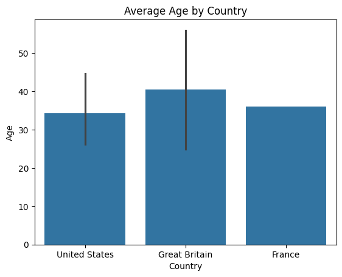

```python
import seaborn as sns
import matplotlib.pyplot as plt

# Bar chart of average Age by Country
sns.barplot(x='Country', y='Age', data=df_excel)
plt.title("Average Age by Country")
plt.show()

print("=" * 80)
```

*Line Plot:*

```
         Date       Close
0  2023-01-01  130.049681
1  2023-01-02  123.297252
2  2023-01-03  112.454919
3  2023-01-04  112.410107
4  2023-01-05  112.187185
================================================================================
```

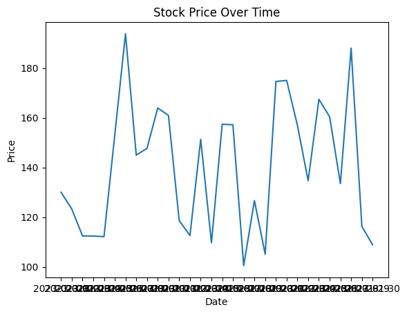

```python
import pandas as pd
import numpy as np
import matplotlib.pyplot as plt

# Read the CSV file back into a new DataFrame
df_new = pd.read_csv("my_stock_data.csv")
print(df_new.head())
print("="*80)

# Plotting stock prices over time using the new DataFrame
plt.plot(df_new['Date'], df_new['Close'])
plt.title("Stock Price Over Time")
plt.xlabel("Date")
plt.ylabel("Price")
plt.show()
print("=" * 80)
```

*Scatter Plot:*

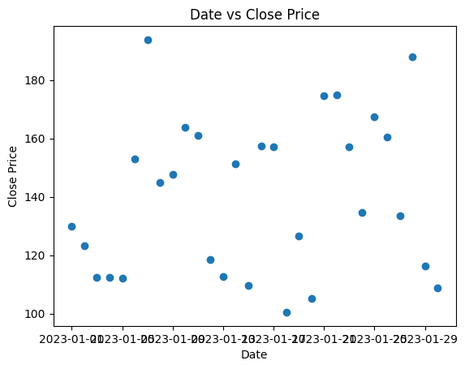

```python
# Scatter plot of Date vs Close price
plt.scatter(df['Date'], df['Close'])
plt.title("Date vs Close Price")
plt.xlabel("Date")
plt.ylabel("Close Price")
plt.show()

print("=" * 80)
```

*Histogram:*

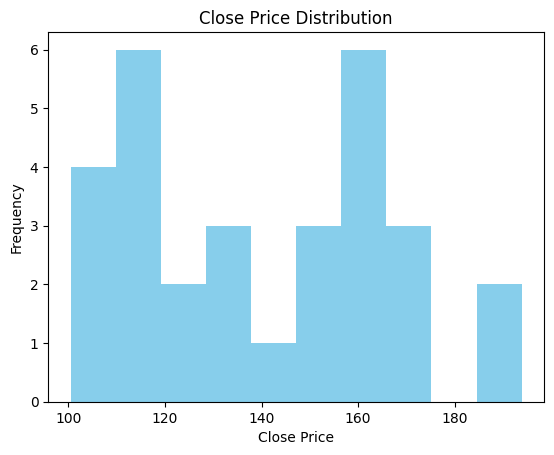

```python
# Distribution of closing prices
plt.hist(df['Close'], bins=10, color='skyblue')
plt.title("Close Price Distribution")
plt.xlabel("Close Price")
plt.ylabel("Frequency")
plt.show()

print("=" * 80)
```

**Unit:-3**

**1. Introduction to Machine Learning**

**Definition:**  
Machine Learning (ML) is a subset of Artificial Intelligence (AI) that enables computers to learn patterns from data and make predictions or decisions without being explicitly programmed for each task.

**2. Types of Machine Learning**

**A. Supervised Learning**

1. The model is trained on labeled data (i.e., data with input-output pairs).
2. Used for tasks like classification and regression.

*Examples:* Spam detection, price prediction, disease diagnosis.

**B. Unsupervised Learning**

1. The model is trained on unlabeled data and discovers hidden patterns or groupings.
2. Used for clustering and dimensionality reduction.

*Examples:* Customer segmentation, market basket analysis.

**==============================================================**

**3. Python Libraries for Machine Learning**

**Popular Libraries:** **1. scikit-learn** – core ML algorithms (classification, regression, clustering)

**2. pandas** – data manipulation

**3. numpy** – numerical operations

**4. matplotlib, seaborn** – data visualization

**==================================================================**

**4. Regression Models**

**A. Linear Regression**

**Definition:** Linear Regression predicts a continuous value based on the linear relationship between input variables (X) and the output (Y).

```
Predicted Prices: [197894.73684211]
MSE: 4432132.963988964
================================================================================
```

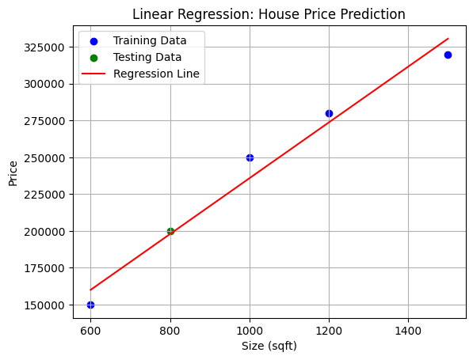

```python
#Linear Regression: Predicting House Price Based on Size with Plot
import pandas as pd
import matplotlib.pyplot as plt
from sklearn.linear_model import LinearRegression
from sklearn.model_selection import train_test_split
from sklearn.metrics import mean_squared_error

# Dataset
data = {'Size_sqft': [600, 800, 1000, 1200, 1500],
        'Price': [150000, 200000, 250000, 280000, 320000]}
df = pd.DataFrame(data)

X = df[['Size_sqft']]
y = df['Price']

# Splitting the dataset
X_train, X_test, y_train, y_test = train_test_split(X, y, test_size=0.2, random_state=42)

# Model
model = LinearRegression()
model.fit(X_train, y_train)

# Prediction
pred = model.predict(X_test)
print("Predicted Prices:", pred)
print("MSE:", mean_squared_error(y_test, pred))
print("=" * 80)

# ------------------ Plotting ------------------
# Plot training data
plt.scatter(X_train, y_train, color='blue', label='Training Data')

# Plot testing data
plt.scatter(X_test, y_test, color='green', label='Testing Data')

# Plot regression line
line = model.predict(X)  # Predict on the full X to draw the line
plt.plot(X, line, color='red', label='Regression Line')

# Labels and legend
plt.xlabel("Size (sqft)")
plt.ylabel("Price")
plt.title("Linear Regression: House Price Prediction")
plt.legend()
plt.grid(True)
plt.show()
```

```
Predicted Salaries: [350007.14285714]
Mean Squared Error: 51.020408163027724
================================================================================
```

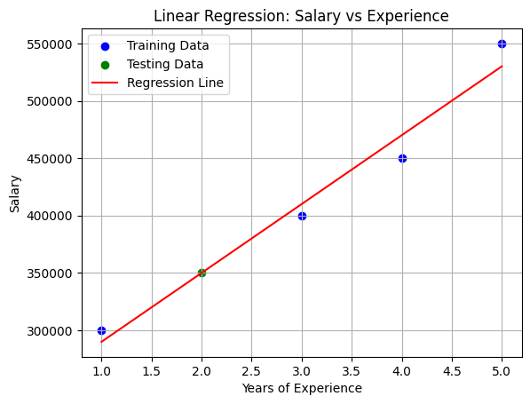

```python
#Python implementation
import pandas as pd
import matplotlib.pyplot as plt
from sklearn.linear_model import LinearRegression
from sklearn.model_selection import train_test_split
from sklearn.metrics import mean_squared_error

# Sample dataset
data = {'Experience': [1, 2, 3, 4, 5],
        'Salary': [300000, 350000, 400000, 450050, 550000]}
df = pd.DataFrame(data)

# Splitting data
X = df[['Experience']]  # Input feature
y = df['Salary']        # Target

X_train, X_test, y_train, y_test = train_test_split(X, y, test_size=0.2, random_state=42)

# Model training
model = LinearRegression()
model.fit(X_train, y_train)

# Prediction
predictions = model.predict(X_test)
print("Predicted Salaries:", predictions)

# Evaluation
mse = mean_squared_error(y_test, predictions)
print("Mean Squared Error:", mse)
print("=" * 80)

# ------------------ Plotting ------------------
# Plot training data
plt.scatter(X_train, y_train, color='blue', label='Training Data')

# Plot testing data
plt.scatter(X_test, y_test, color='green', label='Testing Data')

# Regression line
line = model.predict(X)  # Use all X values to draw the full line
plt.plot(X, line, color='red', label='Regression Line')

# Labels and legend
plt.xlabel("Years of Experience")
plt.ylabel("Salary")
plt.title("Linear Regression: Salary vs Experience")
plt.legend()
plt.grid(True)
plt.show()
```

```
Predicted Scores: [47. 55.]
MSE: 4.499999999999957
================================================================================
```

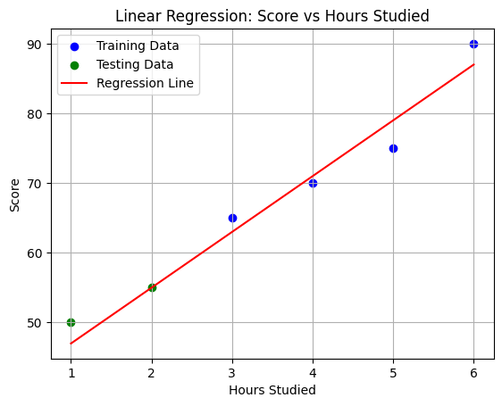

```python
import pandas as pd
import matplotlib.pyplot as plt
from sklearn.linear_model import LinearRegression
from sklearn.model_selection import train_test_split
from sklearn.metrics import mean_squared_error

# Dataset
data = {'Hours_Studied': [1, 2, 3, 4, 5,6],
        'Score': [50, 55, 65, 70, 75,90]}
df = pd.DataFrame(data)

X = df[['Hours_Studied']]
y = df['Score']

# Splitting
X_train, X_test, y_train, y_test = train_test_split(X, y, test_size=0.2, random_state=42)

# Model
model = LinearRegression()
model.fit(X_train, y_train)

# Prediction
pred = model.predict(X_test)
print("Predicted Scores:", pred)
print("MSE:", mean_squared_error(y_test, pred))
print("=" * 80)

# ------------------ Plotting ------------------
# Training points
plt.scatter(X_train, y_train, color='blue', label='Training Data')

# Test points
plt.scatter(X_test, y_test, color='green', label='Testing Data')

# Regression line
line = model.predict(X)
plt.plot(X, line, color='red', label='Regression Line')

# Labels and formatting
plt.xlabel("Hours Studied")
plt.ylabel("Score")
plt.title("Linear Regression: Score vs Hours Studied")
plt.legend()
plt.grid(True)
plt.show()
```

```
Predicted Car Prices: [35000.]
MSE: 2.117582368135751e-22
================================================================================
```

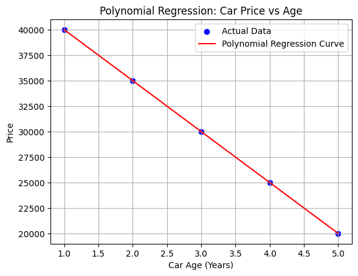

```python
import pandas as pd
import numpy as np
import matplotlib.pyplot as plt
from sklearn.linear_model import LinearRegression
from sklearn.model_selection import train_test_split
from sklearn.preprocessing import PolynomialFeatures
from sklearn.metrics import mean_squared_error

# Dataset
data = {'Age': [1, 2, 3, 4, 5],
        'Price': [40000, 35000, 30000, 25000, 20000]}
df = pd.DataFrame(data)

X = df[['Age']]
y = df['Price']

# Polynomial transformation
poly = PolynomialFeatures(degree=2)
X_poly = poly.fit_transform(X)

# Train-test split
X_train, X_test, y_train, y_test = train_test_split(X_poly, y, test_size=0.2, random_state=42)

# Model training
model = LinearRegression()
model.fit(X_train, y_train)

# Prediction
pred = model.predict(X_test)
print("Predicted Car Prices:", pred)
print("MSE:", mean_squared_error(y_test, pred))
print("=" * 80)

# ------------------ Plotting ------------------
# Generate smoother curve for plotting
X_range = np.linspace(X.min(), X.max(), 100).reshape(-1, 1)
X_range_poly = poly.transform(X_range)
y_range_pred = model.predict(X_range_poly)

# Plot actual data
plt.scatter(X, y, color='blue', label='Actual Data')

# Plot regression curve
plt.plot(X_range, y_range_pred, color='red', label='Polynomial Regression Curve')

# Labels and formatting
plt.xlabel("Car Age (Years)")
plt.ylabel("Price")
plt.title("Polynomial Regression: Car Price vs Age")
plt.legend()
plt.grid(True)
plt.show()
```

```
Predicted Sales: [22.5]
MSE: 6.249999999999254
================================================================================
```

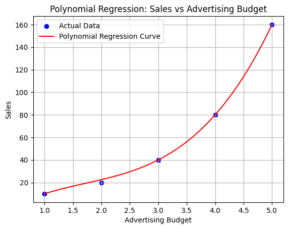

```python
import pandas as pd
import numpy as np
import matplotlib.pyplot as plt
from sklearn.linear_model import LinearRegression
from sklearn.model_selection import train_test_split
from sklearn.preprocessing import PolynomialFeatures
from sklearn.metrics import mean_squared_error

# Dataset
data = {'Ad_Budget': [1, 2, 3, 4, 5],
        'Sales': [10, 20, 40, 80, 160]}
df = pd.DataFrame(data)

X = df[['Ad_Budget']]
y = df['Sales']

# Polynomial transformation (degree 3)
poly = PolynomialFeatures(degree=3)
X_poly = poly.fit_transform(X)

# Train-test split
X_train, X_test, y_train, y_test = train_test_split(X_poly, y, test_size=0.2, random_state=42)

# Model training
model = LinearRegression()
model.fit(X_train, y_train)

# Prediction
pred = model.predict(X_test)
print("Predicted Sales:", pred)
print("MSE:", mean_squared_error(y_test, pred))
print("=" * 80)

# ------------------ Plotting ------------------
# Generate smooth curve
X_range = np.linspace(X.min(), X.max(), 100).reshape(-1, 1)
X_range_poly = poly.transform(X_range)
y_range_pred = model.predict(X_range_poly)

# Plot actual data
plt.scatter(X, y, color='blue', label='Actual Data')

# Plot regression curve
plt.plot(X_range, y_range_pred, color='red', label='Polynomial Regression Curve')

# Labels and formatting
plt.xlabel("Advertising Budget")
plt.ylabel("Sales")
plt.title("Polynomial Regression: Sales vs Advertising Budget")
plt.legend()
plt.grid(True)
plt.show()
```

```
Predicted Population: [1200.]
MSE: 0.0
================================================================================
```

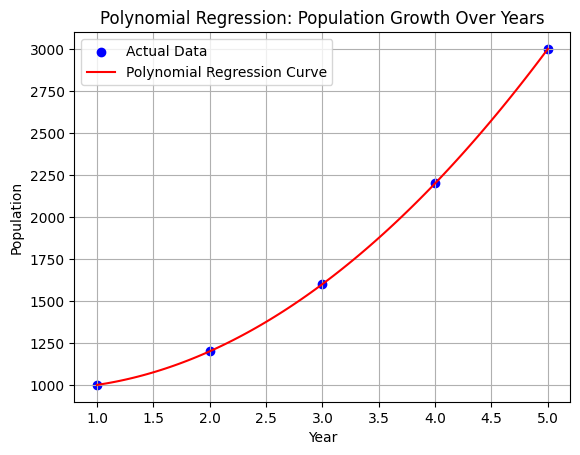

```python
import pandas as pd
import numpy as np
import matplotlib.pyplot as plt
from sklearn.linear_model import LinearRegression
from sklearn.model_selection import train_test_split
from sklearn.preprocessing import PolynomialFeatures
from sklearn.metrics import mean_squared_error

# Dataset
data = {'Year': [1, 2, 3, 4, 5],
        'Population': [1000, 1200, 1600, 2200, 3000]}
df = pd.DataFrame(data)

X = df[['Year']]
y = df['Population']

# Polynomial transformation (degree 2)
poly = PolynomialFeatures(degree=2)
X_poly = poly.fit_transform(X)

# Train-test split
X_train, X_test, y_train, y_test = train_test_split(X_poly, y, test_size=0.2, random_state=42)

# Model training
model = LinearRegression()
model.fit(X_train, y_train)

# Prediction
pred = model.predict(X_test)
print("Predicted Population:", pred)
print("MSE:", mean_squared_error(y_test, pred))
print("=" * 80)

# ------------------ Plotting ------------------
# Generate smoother curve for plotting
X_range = np.linspace(X.min(), X.max(), 100).reshape(-1, 1)
X_range_poly = poly.transform(X_range)
y_range_pred = model.predict(X_range_poly)

# Plot actual data
plt.scatter(X, y, color='blue', label='Actual Data')

# Plot regression curve
plt.plot(X_range, y_range_pred, color='red', label='Polynomial Regression Curve')

# Labels and formatting
plt.xlabel("Year")
plt.ylabel("Population")
plt.title("Polynomial Regression: Population Growth Over Years")
plt.legend()
plt.grid(True)
plt.show()
```

**B. Logistic Regression**

**Definition:** Logistic Regression is used for classification problems. It predicts the probability of a binary outcome (0 or 1).

```
Accuracy: 0.6666666666666666
================================================================================
```

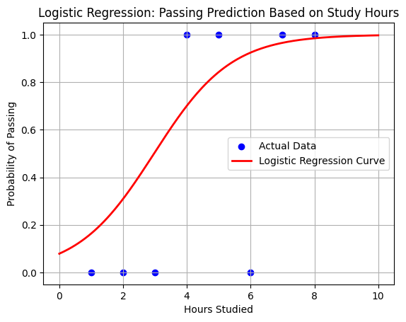

```python
import pandas as pd
import numpy as np
import matplotlib.pyplot as plt
from sklearn.linear_model import LogisticRegression
from sklearn.model_selection import train_test_split
from sklearn.metrics import accuracy_score

# Dataset
data = {'Hours_Studied': [1, 2, 3, 4, 5, 6, 7, 8],
        'Passed': [0, 0, 0, 1, 1, 0, 1, 1]}
df = pd.DataFrame(data)

X = df[['Hours_Studied']]
y = df['Passed']

# Train-test split
X_train, X_test, y_train, y_test = train_test_split(X, y, test_size=0.3, random_state=42)

# Model training
model = LogisticRegression()
model.fit(X_train, y_train)

# Prediction & accuracy
y_pred = model.predict(X_test)
print("Accuracy:", accuracy_score(y_test, y_pred))
print("=" * 80)

# ------------------ Plotting ------------------
# Plotting the logistic regression curve
x_range = np.linspace(0, 10, 200).reshape(-1, 1)
y_prob = model.predict_proba(x_range)[:, 1]

plt.scatter(X, y, color='blue', label='Actual Data')
plt.plot(x_range, y_prob, color='red', linewidth=2, label='Logistic Regression Curve')

# Formatting
plt.xlabel("Hours Studied")
plt.ylabel("Probability of Passing")
plt.title("Logistic Regression: Passing Prediction Based on Study Hours")
plt.legend()
plt.grid(True)
plt.show()
```

```
Accuracy: 0.9736842105263158
================================================================================
Classification Report:
               precision    recall  f1-score   support

           0       0.98      0.95      0.96        43
           1       0.97      0.99      0.98        71

    accuracy                           0.97       114
   macro avg       0.97      0.97      0.97       114
weighted avg       0.97      0.97      0.97       114
```

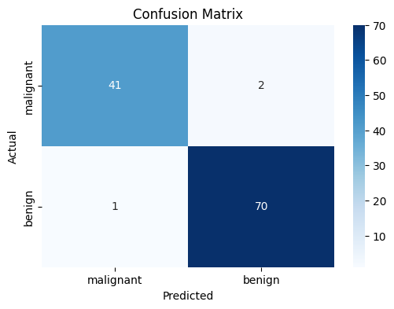

```python
import pandas as pd
import numpy as np
from sklearn.datasets import load_breast_cancer
from sklearn.linear_model import LogisticRegression
from sklearn.model_selection import train_test_split
from sklearn.preprocessing import StandardScaler
from sklearn.metrics import accuracy_score, confusion_matrix, classification_report
import seaborn as sns
import matplotlib.pyplot as plt

# Load dataset
data = load_breast_cancer()
X = data.data
y = data.target

# Standardizing the features
scaler = StandardScaler()
X_scaled = scaler.fit_transform(X)

# Splitting data
X_train, X_test, y_train, y_test = train_test_split(X_scaled, y, test_size=0.2, random_state=42)

# Model training
model = LogisticRegression(max_iter=10000)
model.fit(X_train, y_train)

# Prediction
y_pred = model.predict(X_test)

# Evaluation
print("Accuracy:", accuracy_score(y_test, y_pred))
print("=" * 80)
print("Classification Report:\n", classification_report(y_test, y_pred))

# Confusion matrix
cm = confusion_matrix(y_test, y_pred)
plt.figure(figsize=(6, 4))
sns.heatmap(cm, annot=True, fmt='d', cmap='Blues', xticklabels=data.target_names, yticklabels=data.target_names)
plt.title("Confusion Matrix")
plt.xlabel("Predicted")
plt.ylabel("Actual")
plt.show()
```

```
Accuracy (Multi-class): 1.0
================================================================================
Classification Report:
               precision    recall  f1-score   support

      setosa       1.00      1.00      1.00        19
  versicolor       1.00      1.00      1.00        13
   virginica       1.00      1.00      1.00        13

    accuracy                           1.00        45
   macro avg       1.00      1.00      1.00        45
weighted avg       1.00      1.00      1.00        45
```

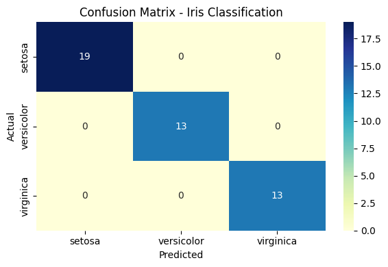

```python
import pandas as pd
import numpy as np
import matplotlib.pyplot as plt
import seaborn as sns
from sklearn.datasets import load_iris
from sklearn.linear_model import LogisticRegression
from sklearn.model_selection import train_test_split
from sklearn.metrics import accuracy_score, classification_report, confusion_matrix

# Load dataset
iris = load_iris()
X = iris.data
y = iris.target

# Train-test split
X_train, X_test, y_train, y_test = train_test_split(X, y, test_size=0.3, random_state=42)

# Model
model = LogisticRegression(max_iter=200)
model.fit(X_train, y_train)

# Predict
y_pred = model.predict(X_test)

# Accuracy
print("Accuracy (Multi-class):", accuracy_score(y_test, y_pred))
print("=" * 80)

# Classification report
print("Classification Report:\n", classification_report(y_test, y_pred, target_names=iris.target_names))

# Confusion matrix
cm = confusion_matrix(y_test, y_pred)
plt.figure(figsize=(6, 4))
sns.heatmap(cm, annot=True, fmt='d', cmap='YlGnBu', xticklabels=iris.target_names, yticklabels=iris.target_names)
plt.title("Confusion Matrix - Iris Classification")
plt.xlabel("Predicted")
plt.ylabel("Actual")
plt.tight_layout()
plt.show()
```

```
Accuracy: 1.0
================================================================================
Classification Report:
               precision    recall  f1-score   support

           0       1.00      1.00      1.00        26
           1       1.00      1.00      1.00        19

    accuracy                           1.00        45
   macro avg       1.00      1.00      1.00        45
weighted avg       1.00      1.00      1.00        45
```

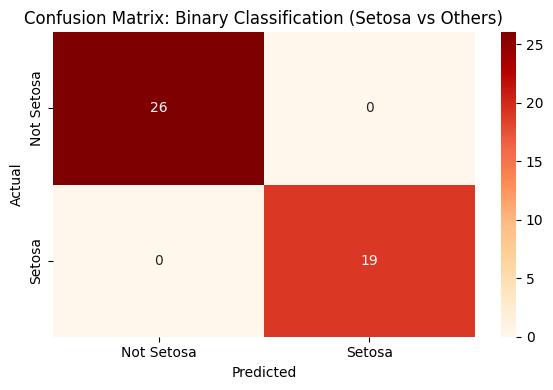

```python
import pandas as pd
import numpy as np
import matplotlib.pyplot as plt
import seaborn as sns
from sklearn.linear_model import LogisticRegression
from sklearn.datasets import load_iris
from sklearn.model_selection import train_test_split
from sklearn.metrics import accuracy_score, confusion_matrix, classification_report

# Load dataset
iris = load_iris()
X = iris.data
y = (iris.target == 0).astype(int)  # Binary classification: Setosa = 1, others = 0

# Train-test split
X_train, X_test, y_train, y_test = train_test_split(X, y, test_size=0.3, random_state=42)

# Train model
model = LogisticRegression()
model.fit(X_train, y_train)

# Predict
y_pred = model.predict(X_test)

# Accuracy
print("Accuracy:", accuracy_score(y_test, y_pred))
print("=" * 80)

# Classification report
print("Classification Report:\n", classification_report(y_test, y_pred))

# Confusion matrix
cm = confusion_matrix(y_test, y_pred)
plt.figure(figsize=(6, 4))
sns.heatmap(cm, annot=True, fmt='d', cmap='OrRd', xticklabels=['Not Setosa', 'Setosa'], yticklabels=['Not Setosa', 'Setosa'])
plt.title("Confusion Matrix: Binary Classification (Setosa vs Others)")
plt.xlabel("Predicted")
plt.ylabel("Actual")
plt.tight_layout()
plt.show()
```

**5. Overfitting and Regularization**

**Overfitting:**

1. Occurs when the model learns too much from training data (including noise).
2. t performs well on training data but poorly on new (test) data.

**Regularization:**

1. A technique to prevent overfitting by penalizing complex models.
2. Helps simplify the model to generalize better on unseen data.